# NYC Taxi Trip Duration Prediction

## NYC pickup locations

Now, let's focus on the taxi pickups in the NYC area. And for that we have to fix the Longitude and latitude to view only the NYC area map. Let's do that now and visualize the pickup locations.

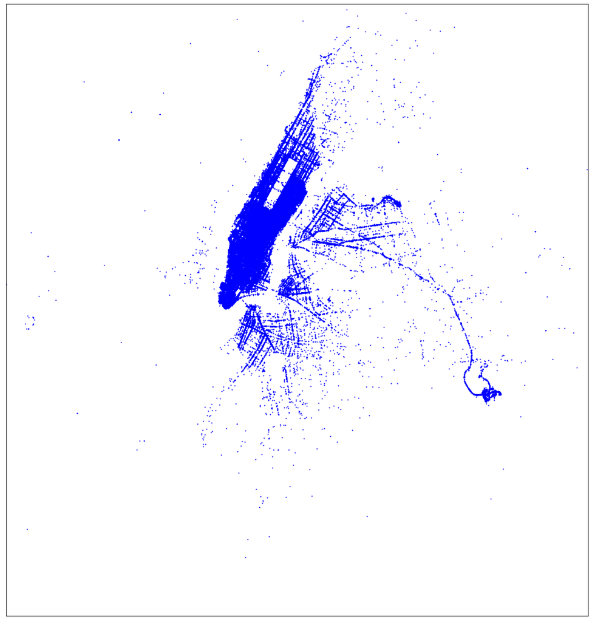

```python
plt.figure(figsize=(20,20))
from mpl_toolkits.basemap import Basemap

# Set the limits of the map to the minimum and maximum coordinates
lat_min = 40.5
lat_max = 40.9
lon_min = -74.2
lon_max = -73.7

# Set the center of the map
cent_lat = (lat_min + lat_max) / 2
cent_lon = (lon_min + lon_max) / 2

#Create the Basemap object with required params.
map = Basemap(llcrnrlon=lon_min,
              llcrnrlat=lat_min,
              urcrnrlon=lon_max,
              urcrnrlat=lat_max,
              resolution='l',
              projection='tmerc',
              lat_0 = cent_lat,
              lon_0 = cent_lon)

#Style the map
# map.drawcounties()

#Fetch the long and lat in form of array
long = np.array(data["pickup_longitude"])
lat = np.array(data["pickup_latitude"])

x, y = map(long, lat)
map.plot(x, y,'bo', markersize=1, alpha=1)
plt.xticks()
plt.show()
```

### Interesting Find

- We can see that most of the taxi pickups were done in the manhattan area as compared to the other areas in NYC.
- A long trail towards the airport shows that the airport is situated quite far from the Manhattan area.

### Observations

- There must have been some long distance rides towards and from the airport.
- Similarly the average duration for the rides picked-up to or for the airport would have been longer.

## NYC dropoff locations

Now let's take a look at the taxi dropoff's

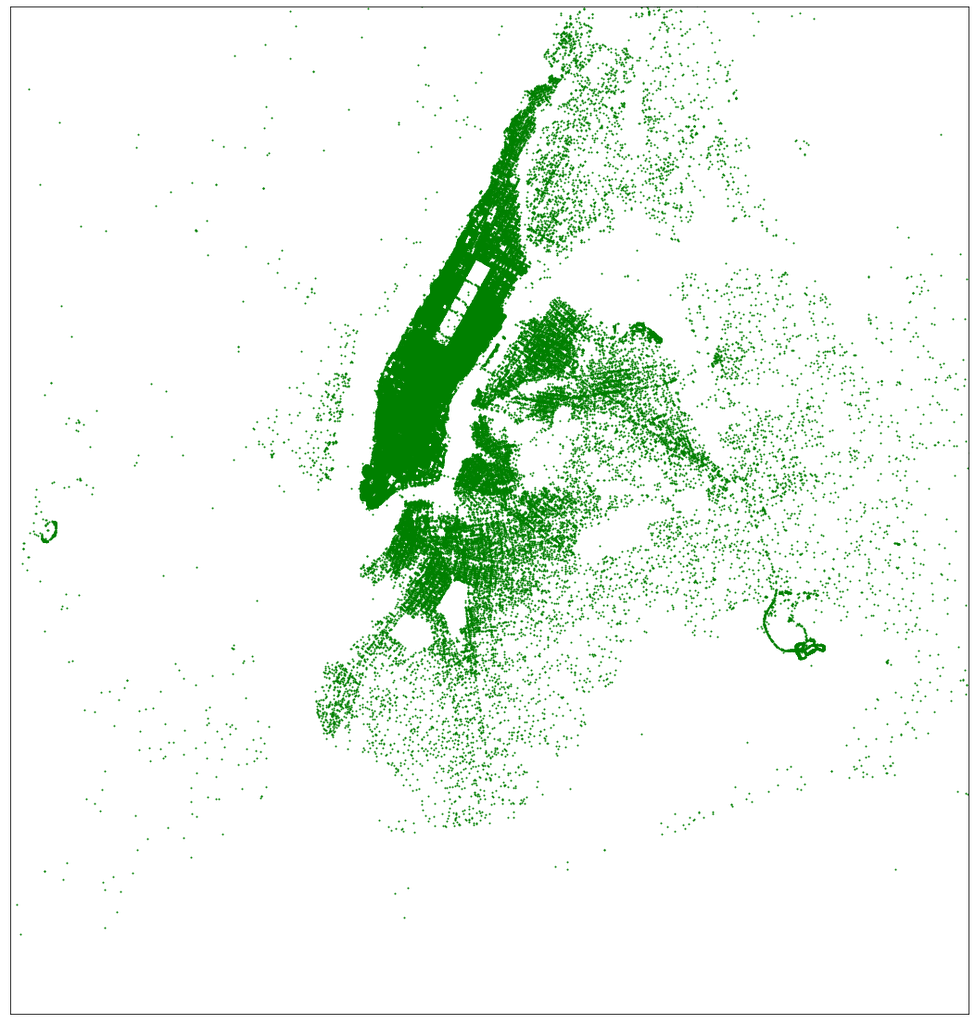

```python
plt.figure(figsize=(20,20))

# Set the limits of the map to the minimum and maximum coordinates
lat_min = 40.5
lat_max = 40.9
lon_min = -74.2
lon_max = -73.7

# Set the center of the map
cent_lat = (lat_min + lat_max) / 2
cent_lon = (lon_min + lon_max) / 2

#Create the Basemap object with required params.
map = Basemap(llcrnrlon=lon_min,
              llcrnrlat=lat_min,
              urcrnrlon=lon_max,
              urcrnrlat=lat_max,
              resolution='l',
              projection='tmerc',
              lat_0 = cent_lat,
              lon_0 = cent_lon)

#Style the map
# map.drawcounties()

#Fetch the long and lat in form of array
long = np.array(data["dropoff_longitude"])
lat = np.array(data["dropoff_latitude"])

x, y = map(long, lat)
map.plot(x, y,'go', markersize=1, alpha=1)
plt.xticks()
plt.show()
```

### Interesting Find:

Dropoff's are much more distributed around the NYC area where still most of the dropoff's were done in the Manhattan.

### Question:

Does that mean there were more dropoff's than the pickup's?

### Idea:

Though the dropoffs seems to be larger in number than the pickups. But we know that for each pickup we have a associated dropoffs in the dataset. It's just that the pickups were majorly concentrated in the Manhattan area.

## Feature Engineering

After looking at the dataset from different perspectives. Let's prepare our dataset before training our model. Since our dataset do not contain very large number of dimensions. We will first try to use feature selection instead of the feature extraction technique.

### Question:

But what's the difference?

- **Feature selection**: we select a subset of the original feature set based on the statistical significance of different parameters.

> Example: Backward elimination, Forward selection, Recursive feature elimination
- **Feature extraction**: we build a new set of features from the original feature set

> Example: PCA, LDA, Kernel PCA

## Feature Selection

#### Intuition

- We will use **backward elimination** technique to select the best features to train our model.
- It displays some statistical metrics with there significance value.
- Like, It shows the **p** values for each feature as per its significance in the whole dataset.
- It also shows the **adjusted R squared** values to identify whether removing or selecting the feature is beneficial or not.
- For now we will only look at the P and adjusted R squared value to decide which features to keep and which needed to be removed.

Let's assign the values to X & Y array from the dataset.

```python
#First chech the index of the features and label
list(zip( range(0,len(data.columns)),data.columns))
```

```
[(0, 'vendorid'),
 (1, 'pickup_date'),
 (2, 'dropoff_date'),
 (3, 'passenger_count'),
 (4, 'trip_distance'),
 (5, 'pickup_longitude'),
 (6, 'pickup_latitude'),
 (7, 'ratecodeid'),
 (8, 'store_and_fwd_flag'),
 (9, 'dropoff_longitude'),
 (10, 'dropoff_latitude'),
 (11, 'payment_type'),
 (12, 'fare_amount'),
 (13, 'extra'),
 (14, 'mta_tax'),
 (15, 'tip_amount'),
 (16, 'tolls_amount'),
 (17, 'improvement_surcharge'),
 (18, 'total_amount'),
 (19, 'type'),
 (20, 'month'),
 (21, 'weekday_num'),
 (22, 'pickup_hour'),
 (23, 'trip_duration'),
 (24, 'distance'),
 (25, 'speed'),
 (26, 'flag_Y'),
 (27, 'vendorid_2.0'),
 (28, 'weekday_num_1'),
 (29, 'weekday_num_2'),
 (30, 'weekday_num_3'),
 (31, 'weekday_num_4'),
 (32, 'weekday_num_5'),
 (33, 'weekday_num_6'),
 (34, 'pickup_hour_1'),
 (35, 'pickup_hour_2'),
 (36, 'pickup_hour_3'),
 (37, 'pickup_hour_4'),
 (38, 'pickup_hour_5'),
 (39, 'pickup_hour_6'),
```

[output cut: 11 more lines]

```
 (51, 'pickup_hour_18'),
 (52, 'pickup_hour_19'),
 (53, 'pickup_hour_20'),
 (54, 'pickup_hour_21'),
 (55, 'pickup_hour_22'),
 (56, 'pickup_hour_23'),
 (57, 'passenger_count_1.0'),
 (58, 'passenger_count_2.0'),
 (59, 'passenger_count_3.0'),
 (60, 'passenger_count_4.0'),
 (61, 'passenger_count_5.0'),
 (62, 'passenger_count_6.0'),
 (63, 'passenger_count_7.0'),
 (64, 'passenger_count_8.0'),
 (65, 'passenger_count_9.0')]
```

```python
data.shape
```

```
(471970, 66)
```

```python
new_data = data.drop('type', axis=1)
new_data.head()
```

|  | vendorid | pickup_date | dropoff_date | passenger_count | trip_distance | pickup_longitude | pickup_latitude | ratecodeid | store_and_fwd_flag | dropoff_longitude | ... | pickup_hour_23 | passenger_count_1.0 | passenger_count_2.0 | passenger_count_3.0 | passenger_count_4.0 | passenger_count_5.0 | passenger_count_6.0 | passenger_count_7.0 | passenger_count_8.0 | passenger_count_9.0 |
| --- | --- | --- | --- | --- | --- | --- | --- | --- | --- | --- | --- | --- | --- | --- | --- | --- | --- | --- | --- | --- | --- |
| 0 | 2.00 | 2016-01-10 01:34:36 | 2016-01-10 01:39:18 | 3.00 | 1.01 | -73.99 | 40.73 | 1.00 | N | -74.00 | ... | 0 | 0 | 0 | 1 | 0 | 0 | 0 | 0 | 0 | 0 |
| 1 | 2.00 | 2016-01-10 01:34:36 | 2016-01-10 01:46:25 | 1.00 | 2.14 | -74.00 | 40.73 | 1.00 | N | -73.98 | ... | 0 | 1 | 0 | 0 | 0 | 0 | 0 | 0 | 0 | 0 |
| 2 | 2.00 | 2016-01-10 01:34:36 | 2016-01-10 02:02:37 | 1.00 | 4.87 | -73.99 | 40.73 | 1.00 | N | -73.94 | ... | 0 | 1 | 0 | 0 | 0 | 0 | 0 | 0 | 0 | 0 |
| 3 | 2.00 | 2016-01-10 01:34:37 | 2016-01-10 01:42:14 | 3.00 | 1.80 | -73.98 | 40.75 | 1.00 | N | -73.96 | ... | 0 | 0 | 0 | 1 | 0 | 0 | 0 | 0 | 0 | 0 |
| 4 | 2.00 | 2016-01-10 01:34:37 | 2016-01-10 01:44:33 | 6.00 | 1.38 | -73.99 | 40.72 | 1.00 | N | -74.00 | ... | 0 | 0 | 0 | 0 | 0 | 0 | 1 | 0 | 0 | 0 |

5 rows × 65 columns

```python
Y = new_data.iloc[:,10].values
X = new_data.iloc[:,range(15,50)].values
```

### Question:

Why few features are not assigned to the X array like features at the index 2,3,10 were missed?

### Idea:

#### Trick for backward elimination:

General equation for multiple linear regression is like

> Y = a0 + a1x1 + a2x2 + ... + anxn

Since, we dont have x0 in our X array so the regressor won't consider the constant value of the equation i.e. **a0**. So to make it count in the equation we will append the selected feature set with a contant series of 1's as a first column. To make it appear like below equation to the statsmodel.

> y = a0x0 + a1x1 + a2x2 + ... + anxn

```python
print("Let's append {} rows of 1's as the first column in the X array".format(X.shape[0]))
```

```
Let's append 471970 rows of 1's as the first column in the X array
```

```python
X1 = np.append(arr = np.ones((X.shape[0],1)).astype(int), values = X, axis = 1)
```

```python
X1.shape
```

```
(471970, 36)
```

There we go, our feature set is now ready for the feature selection model with 1s in the first column for a0 constant.

Let's fit stats model on the X array to figure out an optimal set of features by recursively checking for the highest p value and removing the feature of that index.

### Note:

Here we will take the level of significance as 0.05 i.e. 5% which means that we will reject feature from the list of array and re-run the model till p value for all the features goes below .05 to find out the optimal combination for our model.

```python
import statsmodels.api as sm
X_opt = X1[:,[0,1,3,4,6,7,8,9,10,11]]
X_opt = np.array(X_opt, dtype=float) # <-- this line
regressor_OLS = sm.OLS(endog = Y, exog = X_opt).fit()
regressor_OLS.summary()
```

OLS Regression Results

| Dep. Variable: | y | R-squared: | 0.005 |
| --- | --- | --- | --- |
| Model: | OLS | Adj. R-squared: | 0.005 |
| Method: | Least Squares | F-statistic: | 256.3 |
| Date: | Tue, 13 Dec 2022 | Prob (F-statistic): | 0.00 |
| Time: | 16:53:24 | Log-Likelihood: | -7.6622e+05 |
| No. Observations: | 471970 | AIC: | 1.532e+06 |
| Df Residuals: | 471960 | BIC: | 1.533e+06 |
| Df Model: | 9 |  |  |
| Covariance Type: | nonrobust |  |  |

|  | coef | std err | t | P>\|t\| | [0.025 | 0.975] |
| --- | --- | --- | --- | --- | --- | --- |
| const | 39.3127 | 0.044 | 889.501 | 0.000 | 39.226 | 39.399 |
| x1 | 0.0064 | 0.001 | 6.457 | 0.000 | 0.004 | 0.008 |
| x2 | 4.8057 | 0.146 | 32.881 | 0.000 | 4.519 | 5.092 |
| x3 | -0.0059 | 0.000 | -29.348 | 0.000 | -0.006 | -0.005 |
| x4 | -0.0019 | 0.001 | -1.958 | 0.050 | -0.004 | 1.94e-06 |
| x5 | 0.0018 | 0.000 | 5.768 | 0.000 | 0.001 | 0.002 |
| x6 | 5.311e-06 | 5.62e-07 | 9.451 | 0.000 | 4.21e-06 | 6.41e-06 |
| x7 | 0.0053 | 0.000 | 21.286 | 0.000 | 0.005 | 0.006 |
| x8 | 3.369e-05 | 1.72e-06 | 19.548 | 0.000 | 3.03e-05 | 3.71e-05 |
| x9 | -0.0225 | 0.027 | -0.829 | 0.407 | -0.076 | 0.031 |

| Omnibus: | 1260630.520 | Durbin-Watson: | 1.968 |
| --- | --- | --- | --- |
| Prob(Omnibus): | 0.000 | Jarque-Bera (JB): | 23122854314.825 |
| Skew: | -32.848 | Prob(JB): | 0.00 |
| Kurtosis: | 1085.357 | Cond. No. | 2.86e+05 |

Notes:  
[1] Standard Errors assume that the covariance matrix of the errors is correctly specified.  
[2] The condition number is large, 2.86e+05. This might indicate that there are  
strong multicollinearity or other numerical problems.

```python
X_opt[1]
# x,y = X_opt.shape
# x,y
```

```
array([1.00000000e+00, 2.95000000e+00, 3.00000000e-01, 1.47500000e+01,
       6.00000000e+00, 1.00000000e+00, 7.09000000e+02, 2.86158269e+00,
       1.45298980e+01, 0.00000000e+00])
```

```python
#Select all the features in X array
# X_opt = X1[:,range(0,46)]
X_opt = X1[:,range(0,16)]

X_opt = np.array(X_opt, dtype=float) # <-- this line

regressor_OLS = sm.OLS(endog = Y, exog = X_opt).fit()

#Fetch p values for each feature
p_Vals = regressor_OLS.pvalues

#define significance level for accepting the feature.
sig_Level = 0.05

#Loop to iterate over features and remove the feature with p value less than the sig_level
while max(p_Vals) > sig_Level:
    print("Probability values of each feature \n")
    print(p_Vals)
    X_opt = np.delete(X_opt, np.argmax(p_Vals), axis = 1)
    print("\n")
    print("Feature at index {} is removed \n".format(str(np.argmax(p_Vals))))
    print(str(X_opt.shape[1]-1) + " dimensions remaining now... \n")
    regressor_OLS = sm.OLS(endog = Y, exog = X_opt).fit()
    p_Vals = regressor_OLS.pvalues
    print("=================================================================\n")

#Print final summary
print("Final stat summary with optimal {} features".format(str(X_opt.shape[1]-1)))
regressor_OLS.summary()
```

```
Probability values of each feature

[0.00000000e+000 1.18142731e-018 1.44118568e-107 9.26353910e-243
 2.46455354e-290 0.00000000e+000 2.10480337e-001 1.19519260e-004
 1.10491602e-025 1.29973089e-111 1.49435016e-094 4.52408164e-002
 5.56151961e-030 2.25294172e-001 3.00380214e-001 7.85092674e-001]


Feature at index 15 is removed

14 dimensions remaining now...

=================================================================

Probability values of each feature

[0.00000000e+000 1.15190495e-018 1.49278628e-107 9.50862968e-243
 2.23946309e-290 0.00000000e+000 2.08623559e-001 5.27544424e-005
 1.09306838e-025 1.32505416e-111 1.51672021e-094 4.52928449e-002
 5.04789876e-030 1.86319354e-001 3.16268945e-001]


Feature at index 14 is removed

13 dimensions remaining now...

=================================================================

Probability values of each feature

[0.00000000e+000 1.18611210e-018 1.38143470e-107 1.08027105e-242
 3.28625768e-290 0.00000000e+000 1.21515455e-001 4.87957730e-005
 1.03820030e-025 1.62316458e-111 1.78965988e-094 4.52466168e-002
 3.82935434e-030 9.23320497e-002]


Feature at index 6 is removed

12 dimensions remaining now...

=================================================================

Probability values of each feature

[0.00000000e+000 9.48956823e-019 6.89869456e-108 1.02921506e-242
 2.46207810e-290 0.00000000e+000 1.15936607e-006 9.86615471e-026
 2.12105816e-111 2.31079918e-094 4.53514350e-002 2.24222238e-031
 2.62366335e-001]


Feature at index 12 is removed

11 dimensions remaining now...

=================================================================

Final stat summary with optimal 11 features
```

OLS Regression Results

| Dep. Variable: | y | R-squared: | 0.006 |
| --- | --- | --- | --- |
| Model: | OLS | Adj. R-squared: | 0.006 |
| Method: | Least Squares | F-statistic: | 293.0 |
| Date: | Tue, 13 Dec 2022 | Prob (F-statistic): | 0.00 |
| Time: | 16:53:27 | Log-Likelihood: | -7.6591e+05 |
| No. Observations: | 471970 | AIC: | 1.532e+06 |
| Df Residuals: | 471959 | BIC: | 1.532e+06 |
| Df Model: | 10 |  |  |
| Covariance Type: | nonrobust |  |  |

|  | coef | std err | t | P>\|t\| | [0.025 | 0.975] |
| --- | --- | --- | --- | --- | --- | --- |
| const | 19.6742 | 0.022 | 892.835 | 0.000 | 19.631 | 19.717 |
| x1 | 0.0088 | 0.001 | 8.834 | 0.000 | 0.007 | 0.011 |
| x2 | 0.0264 | 0.001 | 22.104 | 0.000 | 0.024 | 0.029 |
| x3 | 4.8645 | 0.146 | 33.291 | 0.000 | 4.578 | 5.151 |
| x4 | -0.0083 | 0.000 | -36.481 | 0.000 | -0.009 | -0.008 |
| x5 | 19.6742 | 0.022 | 892.835 | 0.000 | 19.631 | 19.717 |
| x6 | 0.0014 | 0.000 | 4.733 | 0.000 | 0.001 | 0.002 |
| x7 | 5.901e-06 | 5.62e-07 | 10.498 | 0.000 | 4.8e-06 | 7e-06 |
| x8 | 0.0056 | 0.000 | 22.429 | 0.000 | 0.005 | 0.006 |
| x9 | 3.553e-05 | 1.72e-06 | 20.608 | 0.000 | 3.22e-05 | 3.89e-05 |
| x10 | -0.0542 | 0.027 | -1.995 | 0.046 | -0.107 | -0.001 |
| x11 | -0.0442 | 0.004 | -11.719 | 0.000 | -0.052 | -0.037 |

| Omnibus: | 1259834.508 | Durbin-Watson: | 1.968 |
| --- | --- | --- | --- |
| Prob(Omnibus): | 0.000 | Jarque-Bera (JB): | 23018317799.831 |
| Skew: | -32.794 | Prob(JB): | 0.00 |
| Kurtosis: | 1082.905 | Cond. No. | 1.67e+18 |

Notes:  
[1] Standard Errors assume that the covariance matrix of the errors is correctly specified.  
[2] The smallest eigenvalue is 1.9e-24. This might indicate that there are  
strong multicollinearity problems or that the design matrix is singular.

### Observations

Finally we have reached the combination of optimum features with each feature having **p value < 0.05**.

### Split Data

Before training our model on the dataset, we need to split the dataset into training and testing datasets. This is required to train our model on the major part of our dataset and test the accuracy of the model on the minor part. Let's split it

```python
#Split raw data
X_train, X_test, y_train, y_test = train_test_split(X,Y, random_state=4, test_size=0.2)

#Split data from the feature selection group
X_train_fs, X_test_fs, y_train_fs, y_test_fs = train_test_split(X_opt,Y, random_state=4, test_size=0.2)
```

```python
X_train[1]
```

```
array([4.16000000e+00, 0.00000000e+00, 3.00000000e-01, 2.49600000e+01,
       1.00000000e+00, 4.00000000e+00, 1.00000000e+01, 1.27200000e+03,
       5.61702513e+00, 1.58972409e+01, 0.00000000e+00, 1.00000000e+00,
       0.00000000e+00, 0.00000000e+00, 0.00000000e+00, 1.00000000e+00,
       0.00000000e+00, 0.00000000e+00, 0.00000000e+00, 0.00000000e+00,
       0.00000000e+00, 0.00000000e+00, 0.00000000e+00, 0.00000000e+00,
       0.00000000e+00, 0.00000000e+00, 0.00000000e+00, 1.00000000e+00,
       0.00000000e+00, 0.00000000e+00, 0.00000000e+00, 0.00000000e+00,
       0.00000000e+00, 0.00000000e+00, 0.00000000e+00])
```

## Feature Extraction

We will use PCA for feature extraction i.e. Principal Component Analysis. It is a statistical procedure that uses an orthogonal transformation to convert a set of observations of possibly correlated variables into a set of values of linearly uncorrelated variables called principal components

### Split Data

Lets split our data first before scaling the features

```python
X_train_pca, X_test_pca, y_train_pca, y_test_pca = train_test_split(X,Y, random_state=4, test_size=0.2)
```

### Scale Data

It is suggested to scale the input varibles first before applying PCA to standardise the variance and avoid the bias. Lets Scale the data using StandardScaler.

```python
from sklearn.preprocessing import StandardScaler
scaler = StandardScaler()
X_train_pca = scaler.fit_transform(X_train_pca)
X_test_pca = scaler.transform(X_test_pca)
```

### PCA application

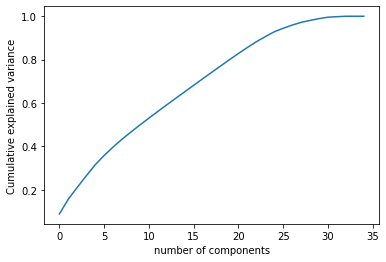

```python
from sklearn.decomposition import PCA
pca = PCA().fit(X_train_pca)
plt.plot(np.cumsum(pca.explained_variance_ratio_))
plt.xlabel("number of components")
plt.ylabel("Cumulative explained variance")
plt.show()
```

```python
arr = np.cumsum(np.round(pca.explained_variance_ratio_, decimals=4)*100)
list(zip(range(1,len(arr)), arr))
```

```
[(1, 8.89),
 (2, 15.740000000000002),
 (3, 21.160000000000004),
 (4, 26.450000000000003),
 (5, 31.550000000000004),
 (6, 35.85),
 (7, 39.72),
 (8, 43.339999999999996),
 (9, 46.65),
 (10, 49.9),
 (11, 53.019999999999996),
 (12, 56.11),
 (13, 59.17),
 (14, 62.18),
 (15, 65.18),
 (16, 68.17),
 (17, 71.14),
 (18, 74.1),
 (19, 77.03999999999999),
 (20, 79.97),
 (21, 82.83),
 (22, 85.6),
 (23, 88.25),
 (24, 90.6),
 (25, 92.83),
 (26, 94.45),
 (27, 95.91),
 (28, 97.16),
 (29, 98.06),
 (30, 98.88),
 (31, 99.53999999999999),
 (32, 99.77),
 (33, 99.97999999999999),
 (34, 99.97999999999999)]
```

### Observation

```python
pca_10 = PCA(n_components=20)
X_train_pca = pca_10.fit_transform(X_train_pca)
X_test_pca = pca_10.transform(X_test_pca)
```

PCA is applied on the training and the test dataset. Our input features are now ready for the regression.

# Correlation Analysis

Correlation analysis is a method of statistical evaluation used to study the strength of a relationship between two or more, numerically measured, continuous variables. This analysis is useful when we need to check if there are possible connections between variables. We will utilize Heatmap for our analysis.

## Heatmap

A heatmap is a graphical representation of data that uses a system of color-coding to represent statistical relationship between different values.

Let's plot the relationship between the features of the **Feature selection** group first

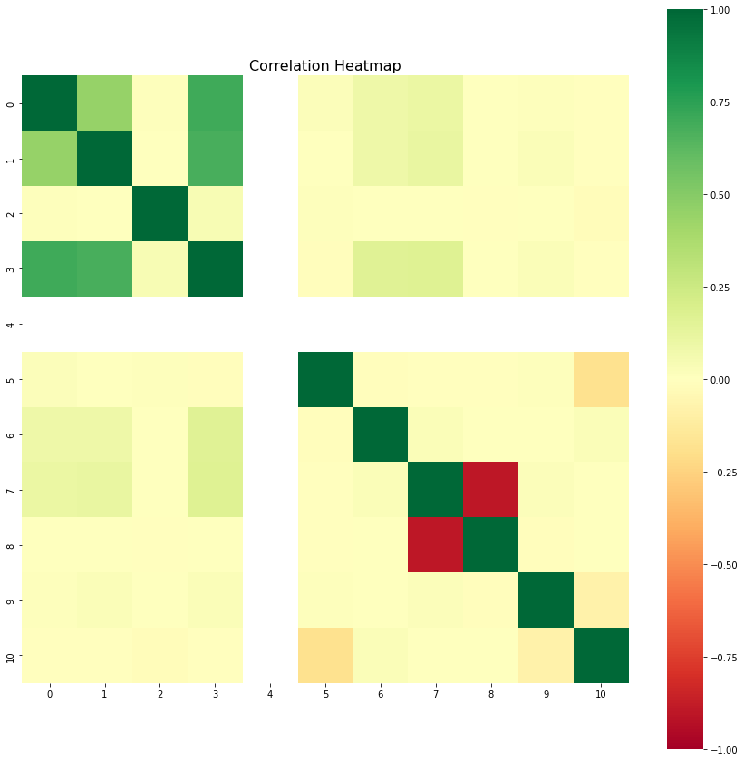

```python
plt.figure(figsize=(15,15))
corr = pd.DataFrame(X_train_fs[:,1:]).corr()
corr.index = pd.DataFrame(X_train_fs[:,1:]).columns
sns.heatmap(corr, cmap='RdYlGn', vmin=-1, vmax=1, square=True)
plt.title("Correlation Heatmap", fontsize=16)
plt.show()
```

### Observations

Let's now plot the relationship between the features of the **Feature extraction** group.

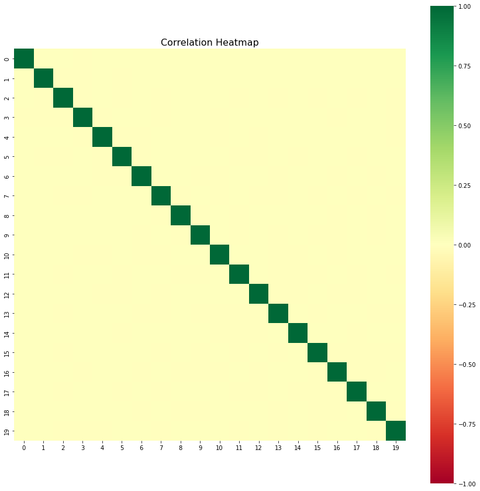

```python
plt.figure(figsize=(15,15))
corr = pd.DataFrame(X_train_pca).corr()
corr.index = pd.DataFrame(X_train_pca).columns
sns.heatmap(corr, cmap='RdYlGn', vmin=-1, vmax=1, square=True)
plt.title("Correlation Heatmap", fontsize=16)
plt.show()
```

### Observations

- All of the features shows **NO** correlation at all. Because feature extraction removes all collinearity.

Let's move on to the Model now.

# Model

We need a model to train on our dataset to serve our purpose of prediciting the NYC taxi trip duration given the other features as training and test set. Since our dependent variable contains continous values so we will use regression technique to predict our output.

## Multiple Linear Regression

It is used to explain the relationship between one continuous dependent variable and two or more independent variables. Let's proceed

## Model training

We will first try with the default instantiation of the regressor object without using any generalization parameter. We will also **not perform any scaling** of the features because linear regression model takes care of that inherently. This is a plus point to use Linear regression model. It is quite fast to train even on very large datasets. So considering the size of our dataset this seems to be the correct approach as of now. Let's see how it performs.

[figure not shown]

```python
#Linear regressor for the raw data
regressor = LinearRegression()
regressor.fit(X_train,y_train)

#Linear regressor for the Feature selection group
regressor1 = LinearRegression()
regressor1.fit(X_train_fs,y_train_fs)

#Linear regressor for the Feature extraction group
regressor2 = LinearRegression()
regressor2.fit(X_train_pca,y_train_pca)
```

```
LinearRegression()
```

## Model prediction

So now, our model has been fitted to the training set. It's time to predict the dependent variable. Let's do that now.

```python
#Predict from the test features of raw data
y_pred = regressor.predict(X_test)

#Predict from the test features of Feature Selection group
y_pred = regressor1.predict(X_test_fs)

#Predict from the test features of Feature Extraction group
y_pred_pca = regressor2.predict(X_test_pca)
```

## Model evaluation

We will evaluate our model's accuracy through two suggested metrics for the regression models. i.e. RMSE and variance score. Where RMSE of 0 and variance of 1 is considered as the best score for a prediction model.

```python
#Evaluate the regressor on the raw data
print('RMSE score for the Multiple LR raw is : {}'.format(np.sqrt(metrics.mean_squared_error(y_test,y_pred))))
print('Variance score for the Multiple LR raw is : %.2f' % regressor.score(X_test, y_test))
print("\n")

#Evaluate the regressor on the Feature selection group
print('RMSE score for the Multiple LR FS is : {}'.format(np.sqrt(metrics.mean_squared_error(y_test_fs,y_pred))))
print('Variance score for the Multiple LR FS is : %.2f' % regressor1.score(X_test_fs, y_test_fs))
print("\n")

#Evaluate the regressor on the Feature extraction group
print('RMSE score for the Multiple LR PCA is : {}'.format(np.sqrt(metrics.mean_squared_error(y_test_pca,y_pred_pca))))
print('Variance score for the Multiple LR PCA is : %.2f' % regressor2.score(X_test_pca, y_test_pca))
```

```
RMSE score for the Multiple LR raw is : 1.2219961461132758
Variance score for the Multiple LR raw is : 0.00


RMSE score for the Multiple LR FS is : 1.2219961461132758
Variance score for the Multiple LR FS is : 0.00


RMSE score for the Multiple LR PCA is : 1.221278696210728
Variance score for the Multiple LR PCA is : 0.00
```

### Observations

- Very poor **Root mean squared** value.
- And the low **variance score** which is also bad.
- Both the models i.e. from the feature selection and the feature extraction group resulted quite bad in prediction.

**Let's find out the reason of this behaviour:-**

```python
X_train.shape
```

```
(377576, 35)
```

```python
#Find linear correlation of each feature with the target variable
from scipy.stats import pearsonr
df1 = pd.DataFrame(np.concatenate((X_train,y_train.reshape(len(y_train),1)),axis=1))
df1.columns = df1.columns.astype(str)

features = df1.iloc[:,:35].columns.tolist()
target = df1.iloc[:,35].name

correlations = {}
for f in features:
    data_temp = df1[[f,target]]
    x1 = data_temp[f].values
    x2 = data_temp[target].values
    key = f + ' vs ' + target
    correlations[key] = pearsonr(x1,x2)[0]

data_correlations = pd.DataFrame(correlations, index=['Value']).T
data_correlations.loc[data_correlations['Value'].abs().sort_values(ascending=False).index]
```

|  | Value |
| --- | --- |
| 2 vs 35 | 0.05 |
| 3 vs 35 | -0.03 |
| 0 vs 35 | -0.02 |
| 11 vs 35 | -0.02 |
| 20 vs 35 | -0.01 |
| 21 vs 35 | -0.01 |
| 6 vs 35 | 0.01 |
| 17 vs 35 | -0.01 |
| 19 vs 35 | -0.01 |
| 7 vs 35 | 0.01 |
| 5 vs 35 | -0.01 |
| 8 vs 35 | 0.00 |
| 23 vs 35 | -0.00 |
| 34 vs 35 | 0.00 |
| 15 vs 35 | 0.00 |
| 30 vs 35 | 0.00 |
| 13 vs 35 | 0.00 |
| 1 vs 35 | 0.00 |
| 22 vs 35 | -0.00 |
| 32 vs 35 | 0.00 |
| 18 vs 35 | -0.00 |
| 10 vs 35 | -0.00 |
| 25 vs 35 | 0.00 |
| 16 vs 35 | 0.00 |
| 24 vs 35 | 0.00 |
| 33 vs 35 | -0.00 |
| 14 vs 35 | 0.00 |
| 28 vs 35 | 0.00 |
| 26 vs 35 | -0.00 |
| 29 vs 35 | -0.00 |
| 27 vs 35 | 0.00 |
| 31 vs 35 | 0.00 |
| 12 vs 35 | -0.00 |
| 9 vs 35 | 0.00 |
| 4 vs 35 | NaN |

## Random Forest Regressor

A random forest is a meta estimator that fits a number of classifying decision trees on various sub-samples of the dataset and use averaging to improve the predictive accuracy and control over-fitting

### Model training

Now we will train the model on the filtered features. Our data has already been split so we will not split the data further.

#### Note:

We used **GridSearch** to tune the **hyperparameters** of random forest regressor to get the best possible test score. We tried various combination of the allowed hyper params values. *But any kind of combination could not produce significantly better results than the default settings. There can be many reasons for that and it totally depends on the type of data we have in hand. Therefore we will not show tuned regressor results here.*

```python
#instantiate the object for the Random Forest Regressor with default params from raw data
regressor_rfraw = RandomForestRegressor(n_jobs=-1)

#instantiate the object for the Random Forest Regressor with default params for Feature Selection Group
regressor_rf = RandomForestRegressor(n_jobs=-1)

# #instantiate the object for the Random Forest Regressor with tuned hyper parameters for Feature Selection Group
# regressor_rf1 = RandomForestRegressor(n_estimators = 26,
#                                      max_depth = 22,
#                                      min_samples_split = 9,
#                                      n_jobs=-1)

#instantiate the object for the Random Forest Regressor for Feature Extraction Group
regressor_rf2 = RandomForestRegressor(n_jobs=-1)


#Train the object with default params for raw data
regressor_rfraw.fit(X_train,y_train)

#Train the object with default params for Feature Selection Group
regressor_rf.fit(X_train_fs,y_train_fs)

# #Train the object with tuned params for Feature Selection Group
# regressor_rf1.fit(X_train_fs,y_train_fs)

# #Train the object with default params for Feature Extraction Group
regressor_rf2.fit(X_train_pca,y_train_pca)

print("\n")
```

### Model prediction

```python
#Predict the output with object of default params for Feature Selection Group
y_pred_rfraw = regressor_rfraw.predict(X_test)

#Predict the output with object of default params for Feature Selection Group
y_pred_rf = regressor_rf.predict(X_test_fs)

# #Predict the output with object of hyper tuned params for Feature Selection Group
# y_pred_rf1 = regressor_rf1.predict(X_test_fs)

#Predict the output with object of PCA params for Feature Extraction Group
y_pred_rfpca = regressor_rf2.predict(X_test_pca)

print("\n")
```

### Model evaluation

```python
#Evaluate the model with default params for raw data
print('RMSE score for the RF regressor raw is : {}'.format(np.sqrt(metrics.mean_squared_error(y_test,y_pred_rfraw))))
print('RMSLE score for the RF regressor raw is : {}'.format(np.sqrt(metrics.mean_squared_log_error(y_test,y_pred_rfraw))))
print('Variance score for the RF regressor raw is : %.2f' % regressor_rfraw.score(X_test, y_test))

print("\n")

#Evaluate the model with default params for Feature Selection Group
print('RMSE score for the RF regressor is : {}'.format(np.sqrt(metrics.mean_squared_error(y_test_fs,y_pred_rf))))
print('RMSLE score for the RF regressor is : {}'.format(np.sqrt(metrics.mean_squared_log_error(y_test_fs,y_pred_rf))))
print('Variance score for the RF regressor is : %.2f' % regressor_rf.score(X_test_fs, y_test_fs))

# print("\n")

# #Evaluate the model with tuned params for Feature Selection Group
# print('RMSE score for the RF regressor1 is : {}'.format(np.sqrt(metrics.mean_squared_error(y_test_fs,y_pred_rf1))))
# print('RMSLE score for the RF regressor1 is : {}'.format(np.sqrt(metrics.mean_squared_log_error(y_test_fs,y_pred_rf1))))
# print('Variance score for the RF regressor1 is : %.2f' % regressor_rf1.score(X_test_fs, y_test_fs))

print("\n")

#Evaluate the model with PCA params  for Feature Extraction Group
print('RMSE score for the RF regressor2 is : {}'.format(np.sqrt(metrics.mean_squared_error(y_test_pca, y_pred_rfpca))))
print('Variance score for the RF regressor2 is : %.2f' % regressor_rf2.score(X_test_pca, y_test_pca))
```

```
RMSE score for the RF regressor raw is : 0.6177551836045877
RMSLE score for the RF regressor raw is : 0.06760445115086916
Variance score for the RF regressor raw is : 0.74


RMSE score for the RF regressor is : 0.6159819806193917
RMSLE score for the RF regressor is : 0.06940586483938525
Variance score for the RF regressor is : 0.75


RMSE score for the RF regressor2 is : 1.2054332634028329
Variance score for the RF regressor2 is : 0.03
```

### Interesting find

Let's see if we can improve this further with the most sought after algorigthm i.e. XGBoost!!

## XGBoost Regressor

XGBoost (Extreme Gradient Boosting) is an optimized distributed gradient boosting library. It uses gradient boosting (GBM) framework at core. It belongs to a family of boosting algorithms that convert weak learners into strong learners. A weak learner is one which is slightly better than random guessing.

'Boosting' here is a sequential process; i.e., trees are grown using the information from a previously grown tree one after the other. This process slowly learns from data and tries to improve its prediction in the subsequent iterations.

### Model training

We will train the model on the filtered features. Our data has already been split so we will not split the data further.

#### Note:

We used **GridSearch** to tune the **hyperparameters** of XGBoost regressor to get the best possible test score. We will compare results from the default regressor and the tuned regressor.

```python
#instantiate the object for the XGBoost Regressor with default params for raw data
regressor_xgbraw = XGBRegressor(n_jobs=-1)

#instantiate the object for the XGBoost Regressor with default params for Feature Selection Group
regressor_xgb = XGBRegressor(n_jobs=-1)

#instantiate the object for the XGBoost Regressor with tuned hyper parameters for Feature Selection Group
regressor_xgb1 = XGBRegressor(n_estimators=300,
                            learning_rate=0.08,
                            gamma=0,
                            subsample=0.75,
                            colsample_bytree=1,
                            max_depth=7,
                            min_child_weight=4,
                            silent=1,
                           n_jobs=-1)

#instantiate the object for the XGBoost Regressor for Feature Extraction Group
regressor_xgb2 = XGBRegressor(n_jobs=-1)


#Train the object with default params for raw data
regressor_xgbraw.fit(X_train,y_train)

#Train the object with default params for Feature Selection Group
regressor_xgb.fit(X_train_fs,y_train_fs)

#Train the object with tuned params for Feature Selection Group
regressor_xgb1.fit(X_train_fs,y_train_fs)

#Train the object with default params for Feature Extraction Group
regressor_xgb2.fit(X_train_pca,y_train_pca)

print("\n")
```

```
[17:21:52] WARNING: ../src/learner.cc:767:
Parameters: { "silent" } are not used.
```

### Model prediction

```python
#Predict the output with object of default params for raw data
y_pred_xgbraw = regressor_xgbraw.predict(X_test)

#Predict the output with object of default params for Feature Selection Group
y_pred_xgb = regressor_xgb.predict(X_test_fs)

#Predict the output with object of hyper tuned params for Feature Selection Group
y_pred_xgb1 = regressor_xgb1.predict(X_test_fs)

#Predict the output with object of PCA params for Feature Extraction Group
y_pred_xgb_pca = regressor_xgb2.predict(X_test_pca)

print("\n")
```

### Model Evaluation

```python
#Evaluate the model with default params for raw data
print('RMSE score for the XGBoost regressor raw is : {}'.format(np.sqrt(metrics.mean_squared_error(y_test,y_pred_xgbraw))))
# print('RMSLE score for the XGBoost regressor is : {}'.format(np.sqrt(metrics.mean_squared_log_error(y_test,y_pred_xgb))))
print('Variance score for the XGBoost regressor raw is : %.2f' % regressor_xgbraw.score(X_test, y_test))

print("\n")

#Evaluate the model with default params for Feature Selection Group
print('RMSE score for the XGBoost regressor is : {}'.format(np.sqrt(metrics.mean_squared_error(y_test_fs,y_pred_xgb))))
# print('RMSLE score for the XGBoost regressor is : {}'.format(np.sqrt(metrics.mean_squared_log_error(y_test,y_pred_xgb))))
print('Variance score for the XGBoost regressor is : %.2f' % regressor_xgb.score(X_test_fs, y_test_fs))

print("\n")

#Evaluate the model with Tuned params for Feature Selection Group
print('RMSE score for the XGBoost regressor1 is : {}'.format(np.sqrt(metrics.mean_squared_error(y_test_fs,y_pred_xgb1))))
# print('RMSLE score for the XGBoost regressor1 is : {}'.format(np.sqrt(metrics.mean_squared_log_error(y_test_fs,y_pred_xgb1))))
print('Variance score for the XGBoost regressor1 is : %.2f' % regressor_xgb1.score(X_test_fs,y_test_fs))

print("\n")

#Evaluate the model with PCA params  for Feature Extraction Group
print('RMSE score for the XGBoost regressor2 is : {}'.format(np.sqrt(metrics.mean_squared_error(y_test_pca, y_pred_xgb_pca))))
print('Variance score for the XGBoost regressor2 is : %.2f' % regressor_xgb2.score(X_test_pca, y_test_pca))
```

```
RMSE score for the XGBoost regressor raw is : 0.6499890856075782
Variance score for the XGBoost regressor raw is : 0.72


RMSE score for the XGBoost regressor is : 0.6572363576720905
Variance score for the XGBoost regressor is : 0.71


RMSE score for the XGBoost regressor1 is : 0.6437985842519771
Variance score for the XGBoost regressor1 is : 0.72


RMSE score for the XGBoost regressor2 is : 1.184400624996338
Variance score for the XGBoost regressor2 is : 0.06
```

### Observations

```python
#Comparing test results for the XGBoost and RF regressor
print("Total sum of difference between the actual and the predicted values for the RF regressor is : %d"%np.abs(np.sum(np.subtract(y_test,y_pred_rf))))
print("Total sum of difference between the actual and the predicted values for the tuned XGB regressor is : %d"%np.abs(np.sum(np.subtract(y_test,y_pred_xgb1))))
```

```
Total sum of difference between the actual and the predicted values for the RF regressor is : 54
Total sum of difference between the actual and the predicted values for the tuned XGB regressor is : 164
```

## Learning curves

Learning curves constitute a great tool to diagnose bias and variance in any supervised learning algorithm. It shows how error changes as the training set size increases. We'll use the learning_curve() [function](http://scikit-learn.org/stable/modules/generated/sklearn.model_selection.learning_curve.html) from the scikit-learn library to generate a learning curve for the regression model. There's no need to put aside a validation set because learning_curve() will take care of that and that's why we will plot the learning curve over whole dataset.

```python
#Define a function to plot learning curve.
def learning_curves(estimator, title, features, target, train_sizes, cv, n_jobs=-1):
    plt.figure(figsize = (14,5))
    train_sizes, train_scores, validation_scores = learning_curve(estimator, features, target, train_sizes = train_sizes, cv = cv, scoring = 'neg_mean_squared_error',  n_jobs=n_jobs)
    train_scores_mean = -train_scores.mean(axis = 1)
    validation_scores_mean = -validation_scores.mean(axis = 1)

    plt.grid()

    plt.plot(train_sizes, train_scores_mean,'o-', color="r", label = 'Training error')
    plt.plot(train_sizes, validation_scores_mean,'o-', color="g", label = 'Validation error')

    plt.ylabel('MSE', fontsize = 14)
    plt.xlabel('Training set size', fontsize = 14)

    title = 'Learning curves for a ' + title + ' model'
    plt.title(title, fontsize = 18, loc='left')

    plt.legend(loc="best")

    return plt

# score curves, each time with 20% data randomly selected as a validation set.
cv = ShuffleSplit(n_splits=10, test_size=0.2, random_state=4)

# Plot learning curve for the RF Regressor
title = "Random Forest Regressor"

# Call learning curve with all dataset i.e. traininig and test combined because CV will take of data split.
learning_curves(regressor_rf, title, X_opt,Y, train_sizes=np.linspace(.1, 1.0, 5), cv=cv, n_jobs=-1)

#Plot learning curve for the XGBoost Regressor
title = "XGBoost Regressor"

# Call learning curve on less number of estimators than the tuned estimator because it took too much time for the compilation.
learning_curves(XGBRegressor(n_estimators=111,
                            learning_rate=0.08,
                            gamma=0,
                            subsample=0.75,
                            colsample_bytree=1,
                            max_depth=7,
                            min_child_weight=4,
                            silent=1), title, X_opt,Y, train_sizes=np.linspace(.1, 1.0, 5), cv=cv, n_jobs=-1)

plt.show()
```

[output not shown]

### Observations:

**Future Scope**

1. Adding more training instances to improve validation curve in the XGBoost model.
2. Increasing the regularization for the learning algorithm. This should decrease the variance and increase the bias towards the validation curve.
3. Reducing the numbers of features in the training data that we currently use. The algorithm will still fit the training data very well, but due to the decreased number of features, it will build less complex models. This should increase the bias and decrease the variance.